# Lab 1: Getting started with R and RStudio

Stat 133, Fall 2020

### Learning Objectives:

> - Get started with R as a scientific calculator
> - Understand pane layout of RStudio
> - Understand the help documentation in R
> - How to install packages
> - Difference between `.R` and `.Rmd` files
> - Get to know markdown syntax

## 1) R and RStudio

- You should have installed **R**
  - R for Mac: https://cran.r-project.org/bin/macosx/
  - R for windows: https://cran.r-project.org/bin/windows/base/
- You should also have installed **RStudio**
  - RStudio download: https://www.rstudio.com/products/rstudio/download/
- R and RStudio are two different things
  - R is both a software and language (like python, matlab, julia, etc)
  - R comes with its minimal Graphical User Interface (R-GUI), but we won’t use this.
  - Instead, we are going to use RStudio as our main working environment.
  - RStudio is much more than a simple GUI; RStudio is technically an *Integrated Development Environment* (IDE).
  - We are going to use mainly RStudio, which provides a nice working environment and development framework.

## 2) R as a scientific calculator

Launch RStudio and notice the default position of the panes (or panels):

- Console (entire left)
- Environment/History (tabbed in upper right)
- Files/Plots/Packages/Help (tabbed in lower right)

**FYI:** you can change the default location of the panes, among many other things: [Customizing RStudio](https://support.rstudio.com/hc/en-us/articles/200549016-Customizing-RStudio). If you have no experience working with R/RStudio, you don’t have to customize anything right now. It’s better if you wait some days until you get a better feeling of the working environment. You will probably be experimenting (trial and error) some time with the customizing options until you find what works for you.

### 2.1) First contact with the R console

If you have never used software in which you have to type commands and code, our best suggestion is that you begin typing basic things in the **console**, using R as a scientific calculator.

For instance, consider the monthly bills of Leia (a fictitious stats undergrad student):

- cell phone $80
- transportation $20
- groceries $527
- gym $10
- rent $1500
- other $83

You can use R to find Leia’s total expenses by typing these commands in the console:

```r
# total expenses
80 + 20 + 527 + 10 + 1500 + 83
```

```
## [1] 2220
```

Often, it will be more convenient to create **objects** or **variables** that store one or more values. To do this, type the name of the variable, followed by the assignment operator `<-`, followed by the assigned value. For example, you can create an object `phone` for the cell phone bill, and then inspect the object by typing its name:

```r
# objects with assigned values
phone <- 80
phone
```

```
## [1] 80
```

All R statements where you create objects are known as “assignments”, and they have this form:

```r
object <- value
```

this means you assign a `value` to a given `object`; you can read the previous assignment as “phone gets 80”.

RStudio has a keyboard shortcut for the arrow operator `<-`: `Alt` + `-` (the minus sign).

Notice that RStudio automagically surrounds `<-` with spaces, which demonstrates a useful code formatting practice. So do yourself (and others) a favor by ALWAYS surrounding an assignment operator with spaces.

Alternatively, you can also use the equals sign `=` as an assignment operator:

```r
coffee = 30
coffee
```

```
## [1] 30
```

You will be working with RStudio a lot, and you will have time to learn most of the bells and whistles RStudio provides. Think about RStudio as your “workbench”. Keep in mind that RStudio is NOT R. RStudio is an environment that makes it easier to work with R, while taking care of many of the little tasks than can be a hassle.

### 2.2) Your Turn

- Make more assignments to create variables `transportation`, `groceries`, `gym`, `rent`, and `other` with their corresponding amounts.

```r
# create variables
transportation <- 20
groceries <- 527
gym <- 10
rent <- 1500
other <- 83
```

- Now that you have all the variables, create a `total` object with the sum of the expenses.

```r
# total expenses
total <- phone + transportation + groceries + gym +
  rent + other
total
```

```
## [1] 2220
```

- Assuming that Leia has the same expenses every month, how much would she spend during a school “semester”? (assume the semester involves five months).

```r
# semester expenses
semester <- total * 5
semester
```

```
## [1] 11100
```

- Maintaining the same assumption about the monthly expenses, how much would Leia spend during a school “year”? (assume the academic year is 10 months).

```r
# year expenses
year <- total * 10
year
```

```
## [1] 22200
```

### 2.3) Object Names

There are certain rules you have to follow when creating objects and variables. Object names cannot start with a digit and cannot contain certain other characters such as a comma or a space. You will be wise to adopt a convention for demarcating words in names.

```r
i_use_snake_case
other.people.use.periods
evenOthersUseCamelCase
```

The following are invalid names (and invalid assignments)

```
# cannot start with a number
5variable <- 5

# cannot start with an underscore
_invalid <- 10

# cannot contain comma
my,variable <- 3

# cannot contain spaces
my variable <- 1
```

This is fine but a little bit too much:

```r
this_is_a_really_long_name <- 3.5
```

### 2.4) Functions

R has many functions. To use a function type its name followed by parenthesis. Inside the parenthesis you pass an input. Most functions will produce some type of output:

```r
# absolute value
abs(10)
abs(-4)

# square root
sqrt(9)

# natural logarithm
log(2)
```

### 2.5) Comments in R

All programming languages use a set of characters to indicate that a specifc part or lines of code are **comments**, that is, things that are not to be executed. R uses the hash or pound symbol `#` to specify comments. Any code to the right of `#` will not be executed by R.

```r
# this is a comment
# this is another comment
2 * 9

4 + 5  # you can place comments like this
```

### 2.6) Case Sensitive

R is case sensitive. This means that `phone` is not the same as `Phone` or `PHONE`

```r
# case sensitive
phone <- 80
Phone <- -80
PHONE <- 8000

phone + Phone
```

```
## [1] 0
```

```r
PHONE - phone
```

```
## [1] 7920
```

### 2.7) Your turn

Take your objects (i.e. variables) `phone`, `transportation`, `groceries`, `gym`, `rent`, and `other` and pass them inside the *combine* function `c()` to create a vector `expenses`.

```r
# vector expenses
expenses <- c(phone, transportation, groceries, gym, rent, other)
```

Now, use the graphing function `barplot()` to produce a barchart of `expenses`:

```r
barplot(expenses)
```

You can see the manual (help) document of `barplot()` by typing `?barplot`; look at the arguments of this function and learn how to:

use `col` to color the bars

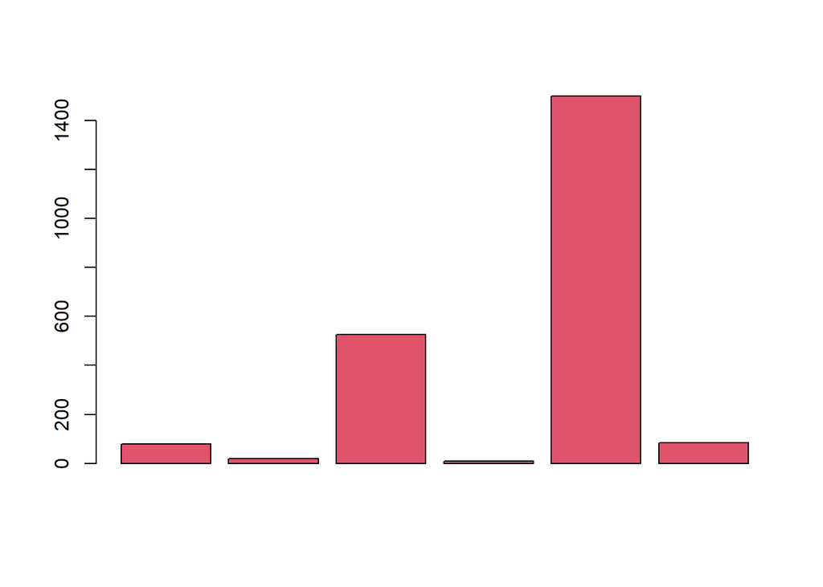

```r
# barchart with colored bars
barplot(expenses, col = 2)
```

use , `horiz` to get a barchart in horizontal orientation

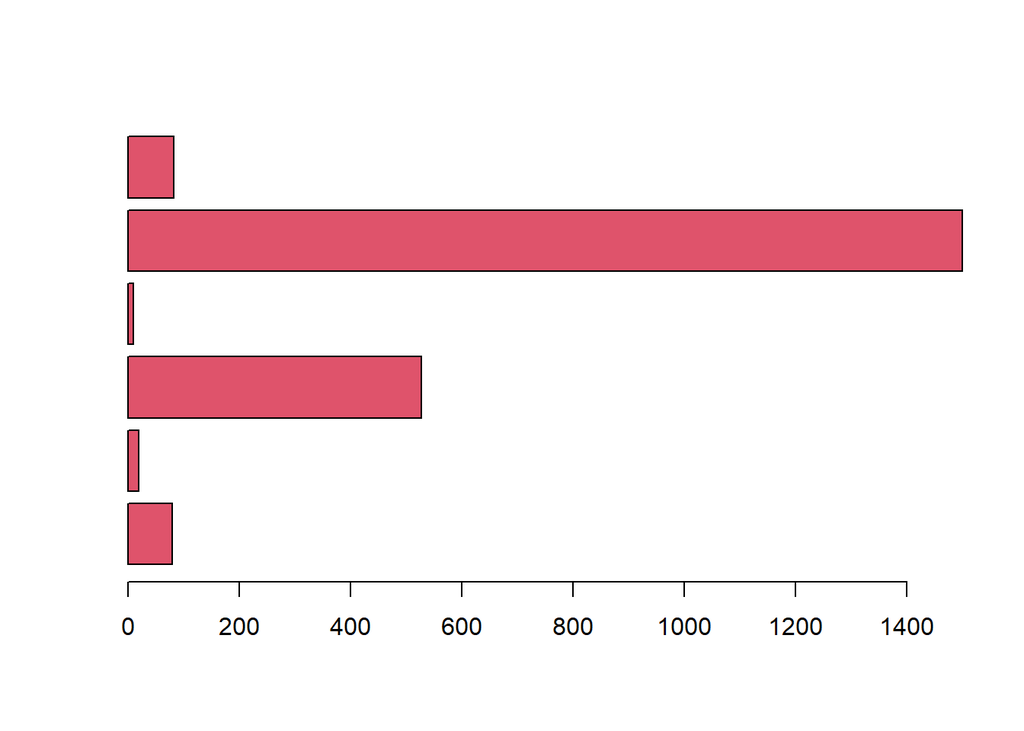

```r
# barchart horizontally oriented
barplot(expenses,  col = 2, horiz = TRUE)
```

use `names.arg` to add labels to the bars (with names of the variables below each of the bars)

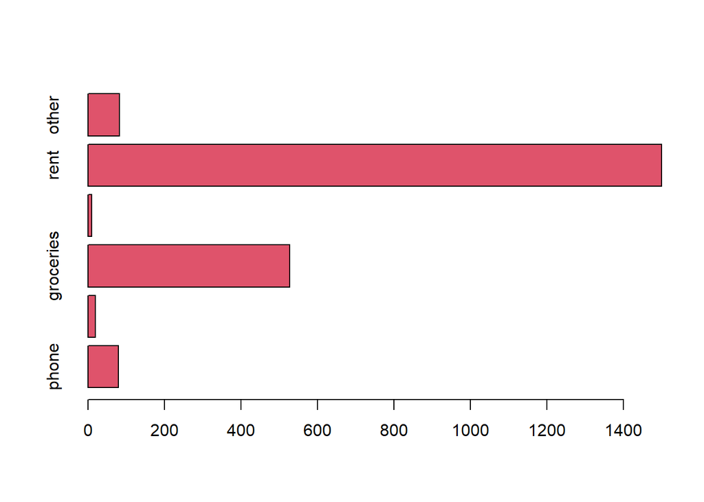

```r
# barchart with bar labels
barplot(expenses, col = 2, horiz = TRUE,
        names.arg = c('phone', 'transportation', 'groceries', 'gym',
                      'rent', 'other'))
```

Find out how to use `sort()` to sort the elements in `expenses`, in order to produce a bar-chart with bars in decreasing order. Also optional, see if you can find out how to display the values of each variable at the top of each bar.

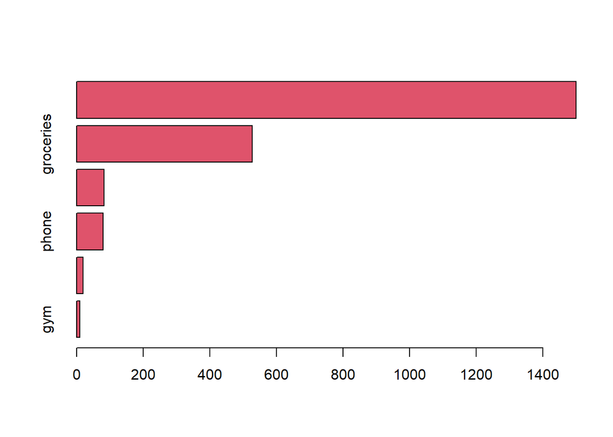

```r
# barchart in decreasing/increasing order
barplot(sort(expenses, decreasing = FALSE),col = 2, horiz = TRUE,
        names.arg = c('gym', 'transportation', 'phone', 'other',
                      'groceries', 'rent'))
```

## 3) Introduction to R Markdown files

Most of the times you won’t be working directly on the console. Instead, you will be typing your commands in some **source file**. The most basic type of source files are known as *R script files*. But there are more flavors of source files. A very convenient type of source file that allow you to mix R code with narrative is an **R markdown file** commonly referred to as `Rmd` file.

### 3.1) Get to know the `Rmd` files

In the menu bar of RStudio, click on **File**, then **New File**, and choose **R Markdown**. Select the default option (Document), and click **Ok**.

**Rmd** files are a special type of file, referred to as a *dynamic document*, that allows to combine narrative (text) with R code. Because you will be turning in most homework assignments as `Rmd` files, it is important that you quickly become familiar with this resource.

Locate the button **Knit HTML** (the one with a knitting icon) and click on it so you can see how `Rmd` files are renderer and displayed as HTML documents.

*R markdown* files use a special syntax called **markdown**. To be more precise, Rmd files let you type text using either: 1) R syntax for code that needs to be executed; 2) markdown syntax to write your *narrative*, and 3) latex syntax for math equations and symbols.

You will have time to learn the basics of this syntax during the semester, and we expect that feel comfortable with markdown at the end of the course.

### 3.2) Your turn

Open a new `Rmd` file in the *source* pane,and include all the previous commands in separated code chunks. Knit the file to get an html document. These are the files that you have to submit to bCourses when you finish the lab work.

## 4) Installing Packages

R comes with a large set of functions and packages. A package is a collection of functions that have been designed for a specific purpose. One of the great advantages of R is that many analysts, scientists, programmers, and users can create their own pacakages and make them available for everybody to use them. R packages can be shared in different ways. The most common way to share a package is to submit it to what is known as **CRAN**, the *Comprehensive R Archive Network*.

You can install a package using the `install.packages()` function. To do this, we recommend that you run this command directly on the console. Do NOT include this command in a code chunk of an Rmd file: you will very likely get an error message when knitting the Rmd file.

To use `install.packages()` just give it the name of a package, surrounded by qoutes, and R will look for it in CRAN, and if it finds it, R will download it to your computer.

```r
# installing (run this on the console!)
install.packages("knitr")
```

You can also install a bunch of packages at once:

```r
# run this command on the console!
install.packages(c("readr", "ggplot2"))
```

Once you installed a package, you can start using its functions by *loading* the package with the function `library()`. By the way, when working on an Rmd file that uses functions from a given package, you MUST include a code chunk with the `library()` command.

```r
# (this command can be included in an Rmd file)
library(knitr)
```

```r
library(knitr)
```

## 5) Getting Help

Because we work with functions all the time, it’s important to know certain details about how to use them, what input(s) is required, and what is the returned output.

There are several ways to get help.

If you know the name of a function you are interested in knowing more, you can use the function `help()` and pass it the name of the function you are looking for:

```r
# documentation about the 'abs' function
help(abs)

# documentation about the 'mean' function
help(mean)
```

Alternatively, you can use a shortcut using the question mark `?` followed by the name of the function:

```r
# documentation about the 'abs' function
?abs

# documentation about the 'mean' function
?mean
```

- How to read the manual documentation
  - Title
  - Description
  - Usage of function
  - Arguments
  - Details
  - See Also
  - Examples!!!

`help()` only works if you know the name of the function your are looking for. Sometimes, however, you don’t know the name but you may know some keywords. To look for related functions associated to a keyword, use double `help.search()` or simply `??`

```r
# search for 'absolute'
help.search("absolute")

# alternatively you can also search like this:
??absolute
```

Notice the use of quotes surrounding the input name inside `help.search()`